# MATH3421 Workshop 2 Solutions

AY24/25 Week 7

## Preliminaries

Recall that if you’re using Rmarkdown for the first time (e.g. on your own machine or every time you use appsanywhere), you may need to execute the following code.

```r
install.packages("rmarkdown")
install.packages("tinytex")
library(rmarkdown)
tinytex::install_tinytex()
```

The latter is used for producing pdf files, and creates a local LaTeX installation. If you’re just wanting to knit to html, you don’t need the tinytex installation. If you’re using the codespaces option of running RStudio, you don’t need the above code chunk at all!

## Question 1 (Bivariate normal density)

Consider the following function for sampling a bivariate normal target (with zero mean, unit marginal variances and correlation $\rho$) via Gibbs sampling.

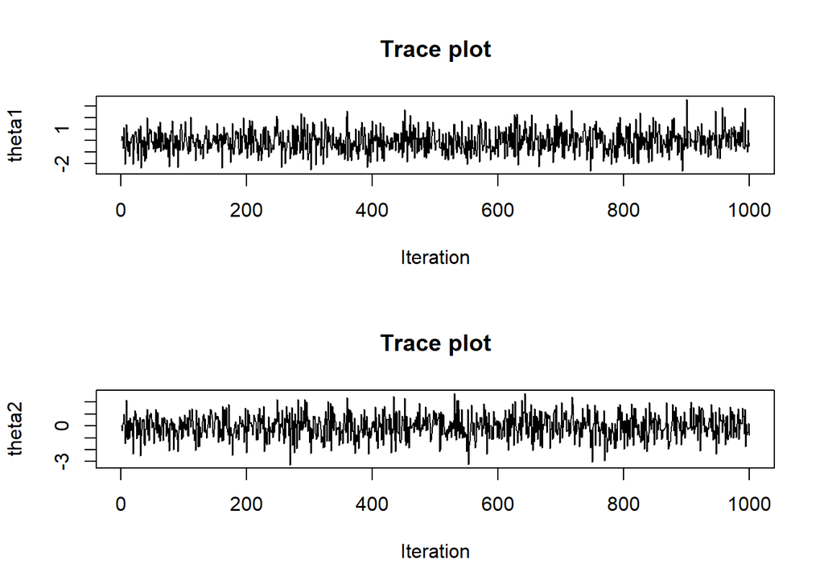

```r
gibbs<-function(N,rho)
 {
  mat <- matrix(ncol=2,nrow=N)
  th1 <- 0
  th2 <- 0
  mat[1, ] <- c(th1,th2)
  for (i in 2:N)
  {
   th1 <- rnorm(1,rho*th2,sqrt(1-rho^2))
   th2 <- rnorm(1,rho*th1,sqrt(1-rho^2))
   mat[i, ] <- c(th1,th2)
  }
  return(mat)
 }

out<-gibbs(1000,0.2)
#Trace plots
par(mfrow=c(2,1))
plot(ts(out[,1]),xlab="Iteration",ylab="theta1",main="Trace plot")
plot(ts(out[,2]),xlab="Iteration",ylab="theta2",main="Trace plot")
```

1. Run the sampler for 1000 iterations with $\rho\in\{0,0.7,0.99\}$ and examine trace plots. E.g. $\rho=0.99$:

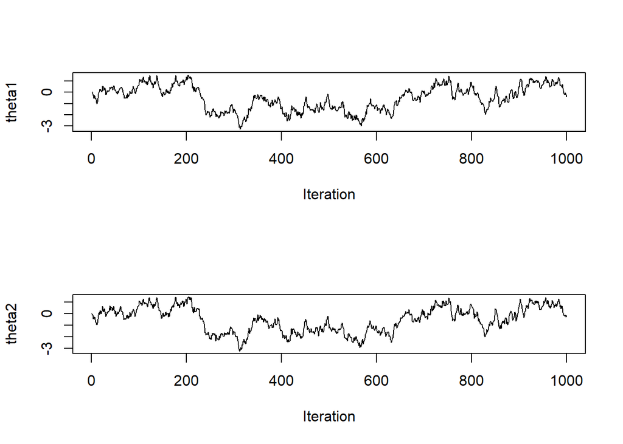

```r
out<-gibbs(1000,0.99)
par(mfrow=c(2,1))
plot(ts(out[,1]),xlab="Iteration",ylab="theta1")
plot(ts(out[,2]),xlab="Iteration",ylab="theta2")
```

Note the terrible mixing due to the high correlation between components!

Now find the effective sample size using the `effectiveSize()` function in the `coda` package. Note that you will need to install the `coda` package when prompted.

```r
require(coda)
effectiveSize(out)
```

```
##      var1      var2
##  7.753123 11.031732
```

2. **Visualising the bivariate chain**. Consider the following modified `gibbs` function that returns both the draws of the Markov chain $\boldsymbol{\theta}^{(0)}, \boldsymbol{\theta}^{(1)},\ldots,\boldsymbol{\theta}^{(N)}$ and all intermediate state values $(\theta_1^{(0)},\theta_2^{(0)})^T, (\theta_1^{(1)},\theta_2^{(0)})^T, (\theta_1^{(1)},\theta_2^{(1)})^T, (\theta_1^{(2)},\theta_2^{(1)})^T, \ldots, (\theta_1^{(N)},\theta_2^{(N)})^T$.

```r
gibbs2<-function(N,rho)
{
  mat <- matrix(ncol=2,nrow=N)
  #Initialise at (-3,-3)^T to demonstrate burn-in
  th1 <- -3
  th2 <- -3
  mat[1, ] <- c(th1,th2)
  state <-c(th1,th2)
  for (i in 2:N)
  {
    th1 <- rnorm(1,rho*th2,sqrt(1-rho^2))
    #store intermediate state
    state <- rbind(state,c(th1,th2))
    th2 <- rnorm(1,rho*th1,sqrt(1-rho^2))
    #store intermediate state
    state <- rbind(state,c(th1,th2))
    mat[i, ] <- c(th1,th2)
  }
  return(list(mat,state))
}
```

We can overlay the path that the sampler takes on a contour plot representing the bivariate target density. The following two functions evaluate the bivariate target density (up to proportionality) and generate the contour plot.

```r
#Function to evaluate target density (up to proportionality)

dbvn<-function(th1,th2,rho)
{
   return(exp(-1/(2*(1-rho^2))*(th1^2+th2^2-2*rho*th1*th2)))
}

#Function to produce a contour plot of the target

plotDens<-function(rho)
{
  s <- seq(-3,3,0.01)
  mat <- outer(s,s,dbvn,rho)
  contour(s,s,mat,nlevels=15,col="grey",xlab="theta 1",ylab="theta 2")
}
```

Finally, produce the contour plot and overlay the sampler output via:

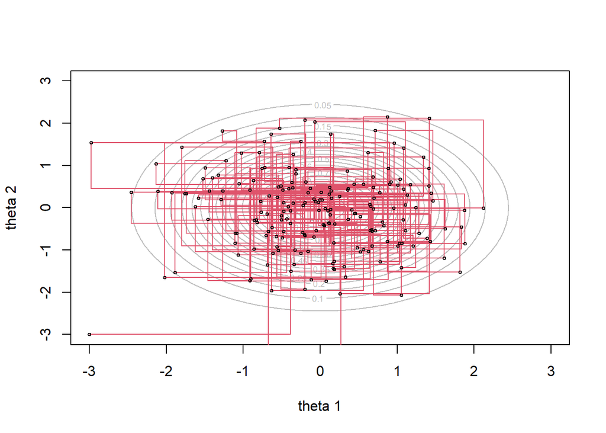

```r
rho <- 0.0
out <- gibbs2(200,rho) #200 iterations for display purposes
plotDens(rho)
lines(out[[2]][,1],out[[2]][,2],type="l",col=2)
lines(out[[1]][,1],out[[1]][,2],type="p",cex=0.5)
```

Try increasing $\rho$:

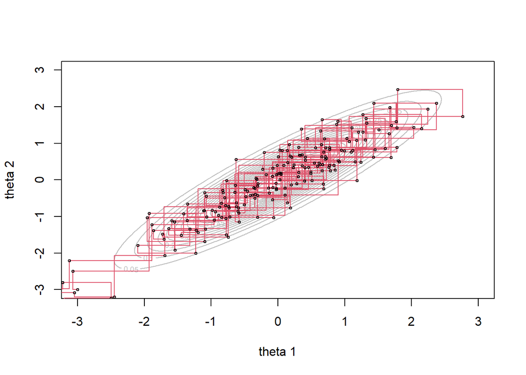

```r
rho <- 0.9
out <- gibbs2(200,rho) #200 iterations for display purposes
plotDens(rho)
lines(out[[2]][,1],out[[2]][,2],type="l",col=2)
lines(out[[1]][,1],out[[1]][,2],type="p",cex=0.5)
```

As discussed in lectures and in part (a), high dependence between components (updated by the Gibbs sampler) can lead to poor mixing (slow exporation of the target space). In part (c) we will consider (two) direct sampling approaches for the bivariate normal target.

3. **Direct sampling**. We are given the following function.

```r
rbivnorm<-function(N=1000,rho=0.99)
{
 mat <- matrix(ncol=2,nrow=N)
 mat[,1] <- rnorm(N)
 mat[,2] <- rnorm(N,rho*mat[,1],sqrt(1-rho^2))
 return(mat)
}
```

This function uses the factorisation
$$\pi(\theta_1,\theta_2) = \pi(\theta_1)\pi(\theta_2|\theta_1)$$
by first drawing $\theta_1$ from its marginal followed by $\theta_2|\theta_1$ from the conditional distribution of $\theta_2$. The intuition behind the validity of this scheme can be found in the solutions to problems class I.

Here’s another way (that we will cover in lectures) for sampling a bivariate normal density using only (independent) draws from univariate normals.

```r
rbivnorm2<-function(N=1000,rho=0.99)
{
  V <- matrix(c(1,rho,rho,1),nrow=2)
  A <- t(chol(V))
  Z <- matrix(rnorm(2*N),nrow=2)
  return(t(A%*%Z))
}
```

The intuition is as follows. Let $\boldsymbol{\theta}\sim N_2(0,\Sigma)$ where
$$\Sigma=\begin{pmatrix} 1 & \rho \\ \rho & 1 \end{pmatrix}.$$
We first find a matrix $A$ such that $A' A = \Sigma$. This can be obtained via a Cholesky decomposition (for example) of $\Sigma$. We may then set
$$\tilde{\boldsymbol{\theta}} = A'Z$$
where $\boldsymbol{Z}\sim N_2(0,I_2)$ and $I_2$ is the $2\times 2$ identity matrix. It is easily checked that the expectation and variance of $\tilde{\boldsymbol{\theta}}$ are as expected, and the distribution must be normal since we have a linear combination of (jointly) normal random variables. Alternatively, we can directly derive the density of $\tilde{\boldsymbol{\theta}}$ using the density of $\boldsymbol{Z}$.

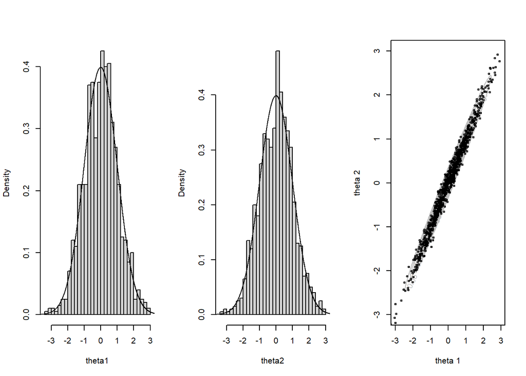

```r
#Example usage and output
out <- rbivnorm()
par(mfrow=c(1,3))
#Histogram of theta1 values with target overlaid
hist(out[,1],40,freq=FALSE,main="",xlab="theta1")
lines(seq(-4,4,0.001),dnorm(seq(-4,4,0.001)))
#Histogram of theta1 values with target overlaid
hist(out[,2],40,freq=FALSE,main="",xlab="theta2")
lines(seq(-4,4,0.001),dnorm(seq(-4,4,0.001)))
#Samples from the joint and contour plot of the target
plotDens(0.99)
lines(out[,1],out[,2],type="p",cex=0.5)
```

## Question 2 (A change point model)

Read in the data:

```r
y <- c(
    4,5,4,1,0,4,3,4,0,6,3,3,4,0,2,6,3,3,5,4,5,3,1,4,4,
    1,5,5,3,4,2,5,2,2,3,4,2,1,3,2,1,1,1,1,1,3,0,0,1,0,
    1,1,0,0,3,1,0,3,2,2,0,1,1,1,0,1,0,1,0,0,0,2,1,0,0,
    0,1,1,0,2,2,3,1,1,2,1,1,1,1,2,4,2,0,0,0,1,4,0,0,0,
    1,0,0,0,0,0,1,0,0,1,0,0)
```

We can plot the data via

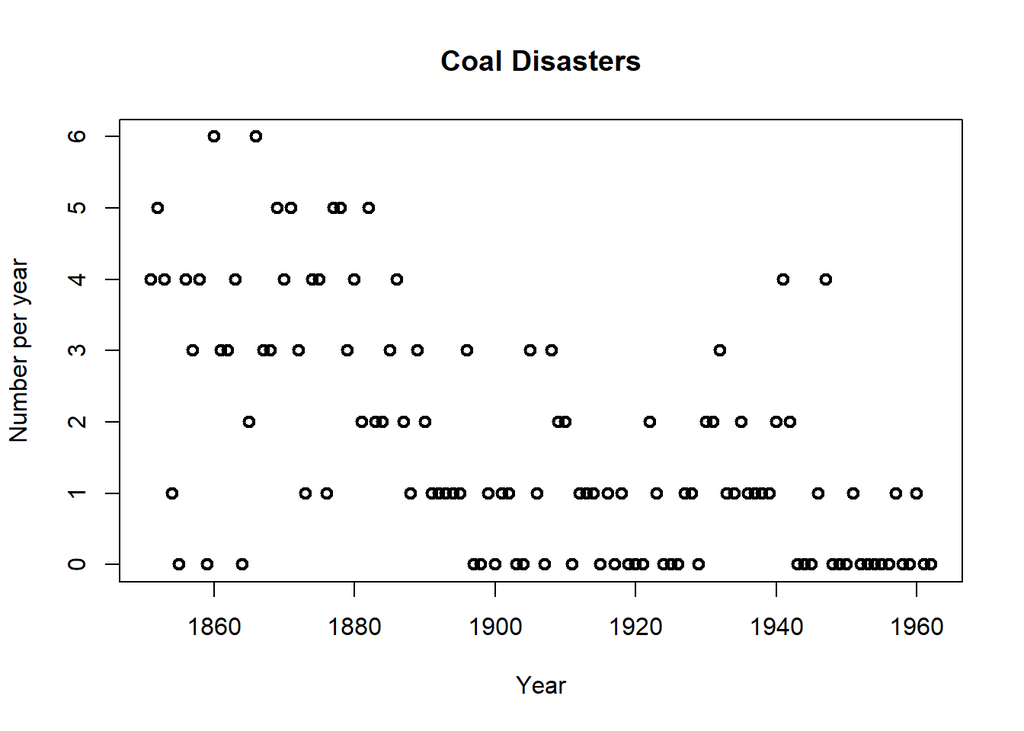

```r
times <- seq(1851,1962,1)
plot(times,y,lwd=2,main="Coal Disasters",xlab="Year",ylab="Number per year")
```

Suppose that $a_1=a_2=b_1=b_2=1$. The following R function takes as arguments the required number of draws and the data (vector) and aims to return a matrix whose rows are (dependent) samples from the posterior $\pi(\theta,\lambda,k|\boldsymbol{y})$.

```r
gibbs<-function(N,data)
{
n <- length(data)
theta <- 1; lambda <- 1; k <- 60  #initial param values
a1 <- 1; a2 <- 1; b1 <- 1; b2 <- 1 #prior hyper-params
probVec <- rep(0,n-1)             #conditional pmf for k
out <- matrix(0,nrow=N,ncol=3)  #store samples here

out[1,] <- c(theta,lambda,k) #store initial sample

for(i in 2:N)
{
 #Update theta
 theta <- rgamma(1,a1+sum(data[1:k]),k+b1)
 #Update lambda
 lambda <- rgamma(1,a2+sum(data[(k+1):n]),n-k+b2)
 #calculate pmf for k
 for(j in 1:(n-1))
 {
  probVec[j] <- exp((lambda-theta)*j)*(theta/lambda)**sum(data[1:j])
 }
 #Update k
 k <- sample(n-1,size=1,prob=probVec)

 out[i,] <- c(theta,lambda,k)
}
return(out)
}
```

1. The completed function is above. Run the code for $N=5,000$ iterations and produce trace plots for each parameter chain.

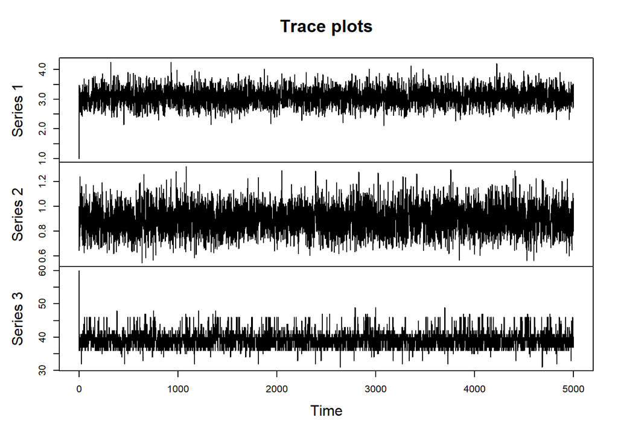

```r
out<-gibbs(5000,y)
plot(ts(out),main="Trace plots")
```

Separate plots with informative labelling would be better practice here! Otherwise, the mixing looks fine.

2. Produce kernel density estimates of the marginal posteriors for $\theta$ and $\lambda$ on the same plot.

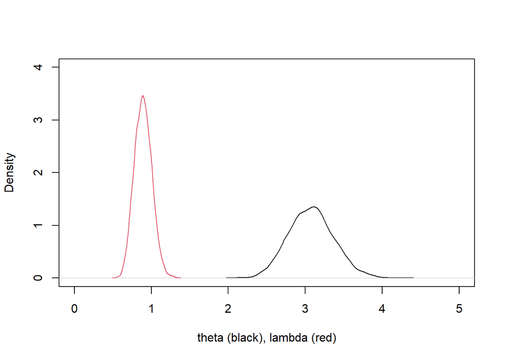

```r
#after removing burn-in
plot(density(out[10:5000,1]),xlim=c(0,5),ylim=c(0,4),main="",xlab="theta (black), lambda (red)",ylab="Density")
lines(density(out[10:5000,2]),col=2)
```

Marginal posterior densities for $\theta$ and $\lambda$ show minimal overlap in terms of high density regions suggesting the assumption of two different rates is plausible.

3. Use R to produce 95% equi-tailed credible intervals for $\theta|\boldsymbol{y}$ and $\lambda|\boldsymbol{y}$:

```r
#theta
quantile(out[10:5000,1],c(0.025,0.975))
```

```
##     2.5%    97.5%
## 2.529404 3.676426
```

```r
#lambda
quantile(out[10:5000,2],c(0.025,0.975))
```

```
##      2.5%     97.5%
## 0.6836709 1.1211864
```

Confirms the comment in (b).

4. Produce a contour plot showing the kernel density estimate of $\pi(\theta,\lambda|\boldsymbol{y})$ using the function `kde2d` in the `MASS` package.

```r
require(MASS)
```

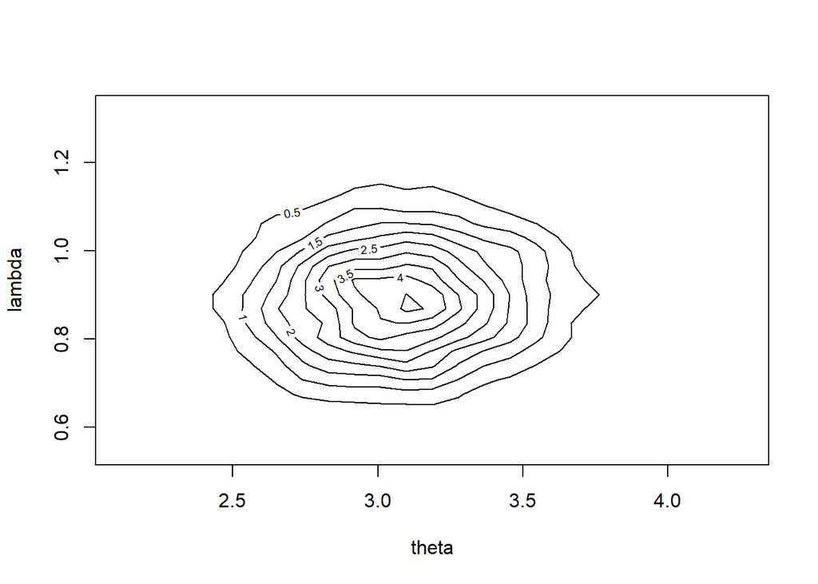

```r
dens<-kde2d(out[10:5000,1],out[10:5000,2])
contour(dens,xlab="theta",ylab="lambda")
```

Suggests little correlation *a posteriori*. A longer run of the sampler would give a better looking plot!

5. What is the modal value of $k$? What year does this correspond to? In light of the plot of the raw data, does this look sensible?

`mode()` in R does not find the mode! We need to write our own function or simply tabulate the number of each distinct values of $k$ via

```r
table(out[10:5000,3])
```

```
##
##   31   32   33   34   35   36   37   38   39   40   41   42   43   44   45   46
##    2    8    9   13   27  505  635  213 1019 1455  561  247  103   34   19  120
##   47   48   49
##   14    4    3
```

which gives $k=40$ as the modal value. This corresponds to year 1890 which seems sensible in light of the data.

*End of solutions!*